# MI Network and Hypergraph Analysis with miEdgeR

## About this vignette

This walkthrough demonstrates how to build mutual-information (MI) networks and hypergraphs from single-cell RNA-seq data using miEdgeR. We extract cluster-specific gene expression, compute pairwise MI, refine networks through percolation and community detection, and finally assemble and visualize a hypergraph of gene modules.

Prerequisites:

R (≥ 4.2.0)

Seurat object with clustering metadata (eg. MG) and optional pseudotime

Packages: miEdgeR, Seurat, igraph, hypergraph, dplyr, ggplot2, ggraph, flextable

## Introduction

This vignette walks through the key steps of MI network construction and higher-order hypergraph analysis. Starting with a Seurat object, we show how to filter for highly variable genes, compute and threshold mutual information (MI), remove noise via percolation, detect communities, and represent those communities as hyperedges.

```
Note: This vignette requires the Zhou et al Control Cortex dataset Microglia (MG) cluster https://doi.org/10.1038/s41591-019-0695-9.
```

## Load Libraries and Data

We load all necessary packages and read in the preprocessed Seurat object. Ensure your object contains a clustering column (MG in seurat demo Zhou et al Control Cortex data) corresponding to cluster IDs.

```r
library(Seurat)
library(miEdgeR)
library(igraph)
library(dplyr)
library(ggplot2)
library(ggraph)
library(flextable)

seurat_obj <- readRDS('Zhou_2020_control.rds')
```

## Data exploration

Exploring the preprocessed Zhou et al Control Cortex data. For this tutorial we will focus on cluster “MG”

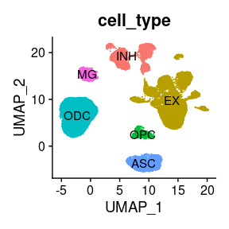

```r
DimPlot(seurat_obj, group.by='cell_type', label=TRUE) + NoLegend()
```

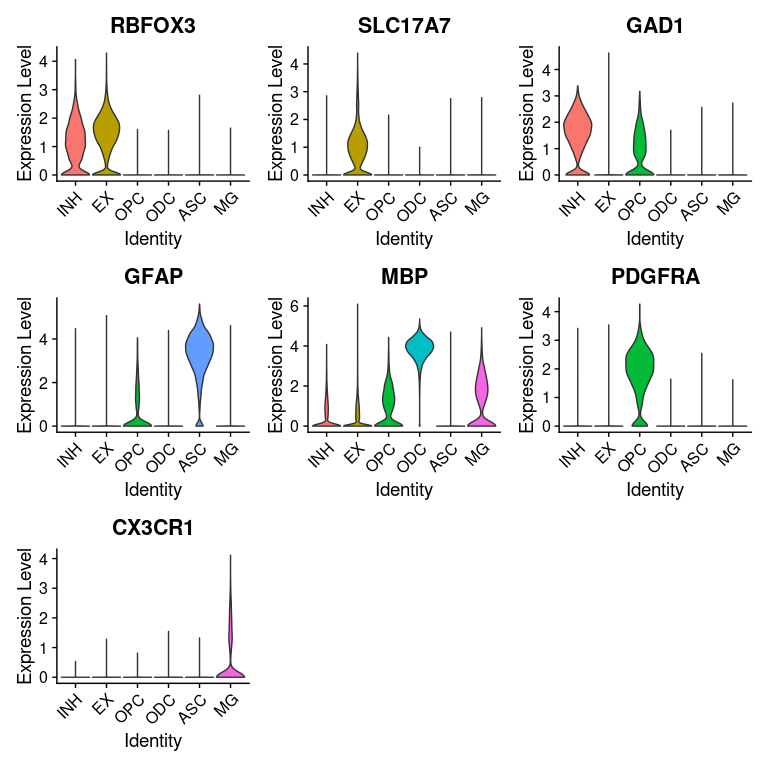

```r
features <- c(
  "RBFOX3",      # neurons
  "SLC17A7",     # excitatory
  "GAD1",        # inhibitory
  "GFAP",        # astrocytes
  "MBP",         # oligodendrocytes
  "PDGFRA",      # OPCs
  "CX3CR1"       # microglia
)

VlnPlot(seurat_obj, features = features, group.by = "cell_type", pt.size = 0)
```

```r
# VlnPlot(seurat_obj, features = features)
```

## Building a Mutual-Information Network

Here we call `compute_mi_network()`, which under the hood:

1. Extracts expression for cluster “MG” (up to 1,500 cells; genes > 5% of cells).
2. Filters to the top 3,000 most variable genes (after removing housekeeping genes).
3. Discretizes expression (adaptive binning) and computes pairwise MI in parallel.
4. Constructs an undirected igraph object by thresholding at the 90th percentile of MI values.

You can adjust `percentile` (e.g. 0.85 for more liberal edges) or supply `fixed_threshold` for absolute MI cutoffs.

Note: computing mi-network can be computationally demanding. We strongly advice to limit the number of cells and genes to the most variable ones

```r
set.seed(123)

result <- compute_mi_network(
  seurat_obj,
  cluster_id = "MG",
  cluster_field = "cell_type",
  assay_name = "RNA",
  counts_layer = "counts",
  data_layer = "data",
  min_expr_pct = 0.05,
  top_n_genes = 3000,
  n_cores = max(1, parallel::detectCores() - 3)
)

mi_matrix <- result$mi_matrix

graph_percentile <- build_mi_graph(mi_matrix,
                                   threshold_method = "percentile",
                                   percentile = 0.90)

cat("Vertices:", vcount(graph_percentile), "\n")
```

```
## Vertices: 2924
```

```r
cat("Edges:", ecount(graph_percentile), "\n")
```

```
## Edges: 427547
```

```r
cat("Density:", graph.density(graph_percentile), "\n")
```

```
## Density: 0.1000478
```

The resulting MI matrix was filtered using the 90th percentile threshold with `build_mi_graph()`, producing a graph with 2924 genes (nodes), 427,547 edges, and a density of ~0.1. This indicates substantial gene-gene co-dependence within the cluster.

## Consensus Edges via Percolation

Real-world networks can be noisy. We apply a simple “percolation” strategy:

- **Pre-filter**: Keep only strong edges (by percentile).
- **Resample** 100 times, each time retaining 60% of edges at random.
- **Consensus**: Edges appearing in ≥ 50% of iterations are considered stable.

This yields a consensus graph that filters out spurious edges.

In miEdgeR v0.2+, percolation + edge canonicalization + weight hygiene are handled inside percolate_graph().

```r
g_consensus <- percolate_graph(
  graph_percentile,
  n_iterations   = 100,
  edge_fraction  = 0.6,
  freq_threshold = 0.5,
  percentile     = 0.9
)

cat("Consensus vertices:", vcount(g_consensus), "\n")
```

```
## Consensus vertices: 2924
```

```r
cat("Consensus edges:", ecount(g_consensus), "\n")
```

```
## Consensus edges: 41999
```

```r
cat("Consensus density:", graph.density(g_consensus), "\n")
```

```
## Consensus density: 0.009827946
```

## Community Detection

We use detect_communities() which performs community detection and overlap expansion consistently.

```r
set.seed(123)

comm_out <- detect_communities(
  g_consensus,
  min_size          = 10,
  overlap_threshold = 0.2
)

# v0.2 may return either:
# - a plain list of communities
# - or a richer list with $communities, $bridge, $gene2mod

# v0.2 canonical structure
stopifnot("groups" %in% names(comm_out))

large_communities <- comm_out$groups

cat("Communities (size >= 10):", length(large_communities), "\n")
```

```
## Communities (size >= 10): 2
```

```r
cat("Sizes:", sapply(large_communities, length), "\n")
```

```
## Sizes: 23 969
```

## Clustering coefficient

Compute additional network metrics for the consensus graph.

```r
clustering_coeff <- transitivity(g_consensus, type = "global")
cat("Global clustering coefficient:", clustering_coeff, "\n")
```

```
## Global clustering coefficient: 0.4478631
```

```r
degree_centrality      <- degree(g_consensus)
betweenness_centrality <- betweenness(g_consensus)
closeness_centrality   <- closeness(g_consensus)

top_degree      <- names(sort(degree_centrality, decreasing = TRUE))[1:10]
top_betweenness <- names(sort(betweenness_centrality, decreasing = TRUE))[1:10]
top_closeness   <- names(sort(closeness_centrality, decreasing = TRUE))[1:10]

centrality_table <- data.frame(
  Metric = c("Degree", "Betweenness", "Closeness"),
  Top_Genes = c(
    paste(top_degree, collapse = ", "),
    paste(top_betweenness, collapse = ", "),
    paste(top_closeness, collapse = ", ")
  ),
  stringsAsFactors = FALSE
)

ft_centrality <- flextable::flextable(centrality_table) %>%
  flextable::autofit() %>%
  flextable::set_header_labels(Metric = "Centrality Metric", Top_Genes = "Top 10 Genes") %>%
  flextable::bg(part = "header", bg = "gray") %>%
  flextable::theme_vanilla()

ft_centrality
```

| Centrality Metric | Top 10 Genes |
| --- | --- |
| Degree | VPS13C, SENP6, ATRX, COP1, BIRC6, USP34, PIAS1, DOCK2, SETX, GNB1 |
| Betweenness | VPS13C, SENP6, FTH1, RHBDF2, GNB1, COP1, FTL, ATRX, ALOX5, SETX |
| Closeness | SPP1, AC131944.1, HSPA1A, HSPA1B, MTRNR2L8, MTRNR2L1, LINC01320, DHFR, MTRNR2L12, VPS13C |

## Network Visualization

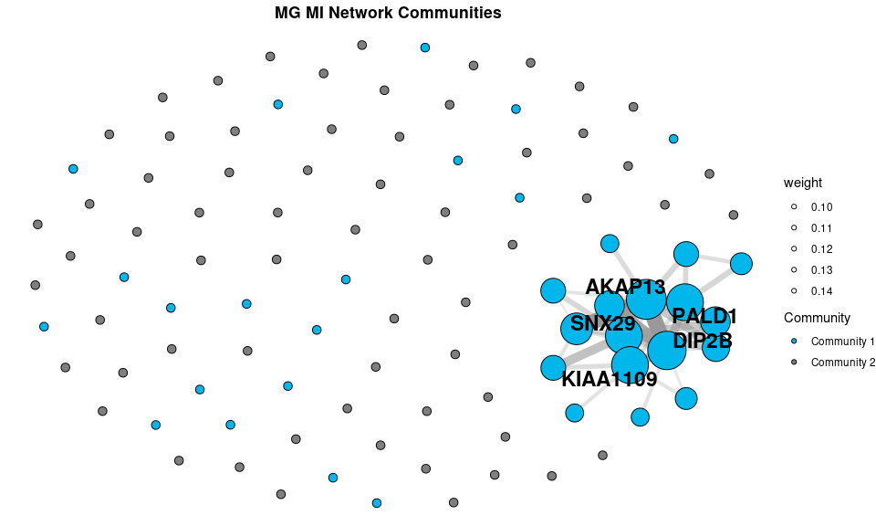

```r
plot_mi_network(g_consensus, large_communities, title = "MG MI Network Communities")
```